# All Countries Environmental Data

## Method: MCA

Multiple correspondence analysis (MCA) is an extension of correspondence analysis(CA) which allows one to analyze the pattern of relationships of several categorical dependent variables. As such, it can also be seen as a generalization of principal component analysis when the variables to be analyzed are categorical instead of quantitative. Because MCA has been (re)discovered many times, equivalent methods are known under several different names such as optimal scaling, optimal or appropriate scoring, dual scaling, homogeneity analysis,scalogram analysis, and quantiﬁcation method.

**Interpreting MCA** Multiple correspondence analysis locates all the categories in a Euclidean space.

- The first two dimensions of this space are plotted to examine the associations among the categories.
- The top-right quadrant of the plot shows the categories.
- The bottom-left quadrant shows the association.
- This interpretation is based on points found in approximately the same direction from the origin and in approximately the same region of the space. Distances between points do not have a straightforward interpretation.

## Dataset

- Data: Measurements of environment conditions in Countries
- Rows: There are 137 observations, 1 for each country.
- Columns: Total 29 variables
- Qualitative: Country (nominal), Happiness (Ordinal).
- Quantitative: Aspect, Slope Crop Land, Tree Canopy Wind Cloud & Multiple variables for Temp & Rain
- Structure of Data

```r
str(country_env_df)
```

```
'data.frame':   137 obs. of  29 variables:
 $ Country                : Factor w/ 137 levels "Afghanistan",..: 1 2 3 4 5 6 7 8 9 10 ...
 $ Happiness_Rank         : Ord.factor w/ 3 levels "VH"<"H"<"U": 3 2 2 3 1 3 1 1 2 2 ...
 $ accessibility_to_cities: num  317.7 73.8 1212.8 378.2 209.2 ...
 $ elevation              : num  1832 652 557 1061 683 ...
 $ aspect                 : num  201 192 185 174 145 ...
 $ slope                  : num  1.516 1.89 0.171 0.193 0.624 ...
 $ cropland_cover         : num  9.51 23.35 3.69 2.79 21.96 ...
 $ tree_canopy_cover      : num  0.375 12.805 0.177 19.87 8.834 ...
 $ isothermality          : num  35.9 33.2 40.3 64.3 49.9 ...
 $ rain_coldestQuart      : num  128.72 392.51 25.29 8.05 79.09 ...
 $ rain_driestMonth       : num  1.722 40.088 0.935 0.26 17.183 ...
 $ rain_driestQuart       : num  8.3 138.15 6.09 4.43 60.49 ...
 $ rain_mean_annual       : num  311.3 1151.1 79.5 1023.4 539.9 ...
 $ rain_seasonailty       : num  91.6 38.5 67.1 91.5 48.3 ...
 $ rain_warmestQuart      : num  12.69 138.33 9.51 318.54 183.14 ...
 $ rain_wettestMonth      : num  67.8 159 13.4 202.2 79.2 ...
 $ rain_wettestQuart      : num  175.8 435.9 33.3 524.3 211.7 ...
 $ temp_annual_range      : num  40.3 27.1 36.5 21.5 26.8 ...
 $ temp_coldestQuart      : num  -0.261 3.58 13.152 18.794 8.024 ...
 $ temp_diurnal_range     : num  14.72 9.11 14.87 13.85 13.46 ...
 $ temp_driestQuart       : num  21.1 19.6 26.9 18.9 11.1 ...
 $ temp_max_warmestMonth  : num  32 26.3 41.5 31 28.2 ...
 $ temp_mean_annual       : num  11.5 11.5 23 21.6 14.2 ...
 $ temp_min_coldestMonth  : num  -8.312 -0.806 5.058 9.549 1.443 ...
 $ temp_seasonality       : num  88.2 62.7 75.1 18.5 47.6 ...
 $ temp_warmestQuart      : num  22.7 19.6 32.5 23.3 20.2 ...
 $ temp_wettestQuart      : num  3.95 5.27 20.81 22.76 16.48 ...
 $ wind                   : num  3.43 2.47 4.03 2.16 4.27 ...
 $ cloudiness             : num  114.2 181.1 90.7 187.5 159 ...
```

- Research Question

How do the 137 countries differ on these variables?

## Analysis

Let’s observe the distribution of each variables to get an intuition of how we can bin these variables. It’s important to have nearly equal number of observations in the each bin and to try to cut the variables in a way to so that each new binned distribution is nearly Gaussian. We can also verify that our binning is appropiate by calculating Spearman Correlation for each of original variable and binned variable, the correlation coefficient should be close to 1.

### Density plot

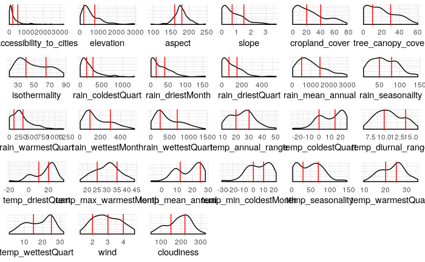

```r
plot_bins <- function(df, col) {
  plot_col <- ggplot(df) + aes(df[,col]) +  geom_density() +
    geom_vline(xintercept = cut_points[[col]], color = 'red') +
    xlab(col) + theme_minimal() + ylab(NULL) +
  theme(axis.text.y = element_blank())
  return(plot_col)
}

bin_hist_list <- lapply(colnames(country_env_df_for_pca), function (col) plot_bins(country_env_df_for_pca, col))

plot_grid(plotlist=bin_hist_list)
```

### Binning

Structure of Data after binning based on above observation.

```
'data.frame':   137 obs. of  27 variables:
 $ accessibility_to_cities: Factor w/ 3 levels "1","2","3": 2 1 3 2 2 1 3 1 1 1 ...
 $ elevation              : Factor w/ 3 levels "1","2","3": 3 2 2 3 2 3 2 3 2 1 ...
 $ aspect                 : Factor w/ 3 levels "1","2","3": 3 3 3 2 1 3 3 2 1 2 ...
 $ slope                  : Factor w/ 3 levels "1","2","3": 3 3 1 1 1 3 1 2 2 1 ...
 $ cropland_cover         : Factor w/ 3 levels "1","2","3": 1 2 1 1 2 2 1 2 2 3 ...
 $ tree_canopy_cover      : Factor w/ 3 levels "1","2","3": 1 2 1 2 1 1 1 3 1 2 ...
 $ isothermality          : Factor w/ 3 levels "1","2","3": 1 1 2 2 2 1 2 1 1 2 ...
 $ rain_coldestQuart      : Factor w/ 3 levels "1","2","3": 1 3 1 1 1 1 1 2 1 1 ...
 $ rain_driestMonth       : Factor w/ 3 levels "1","2","3": 1 3 1 1 2 2 1 3 2 1 ...
 $ rain_driestQuart       : Factor w/ 3 levels "1","2","3": 1 2 1 1 1 1 1 3 1 1 ...
 $ rain_mean_annual       : Factor w/ 3 levels "1","2","3": 1 2 1 2 2 2 1 2 1 3 ...
 $ rain_seasonailty       : Factor w/ 3 levels "1","2","3": 3 1 2 3 1 1 2 1 1 3 ...
 $ rain_warmestQuart      : Factor w/ 3 levels "1","2","3": 1 2 1 3 2 2 2 3 1 3 ...
 $ rain_wettestMonth      : Factor w/ 3 levels "1","2","3": 1 2 1 2 1 1 1 2 1 3 ...
 $ rain_wettestQuart      : Factor w/ 3 levels "1","2","3": 1 2 1 2 1 1 1 2 1 3 ...
 $ temp_annual_range      : Factor w/ 3 levels "1","2","3": 3 2 3 2 2 3 2 2 3 2 ...
 $ temp_coldestQuart      : Factor w/ 3 levels "1","2","3": 1 2 2 3 2 1 2 1 2 3 ...
 $ temp_diurnal_range     : Factor w/ 3 levels "1","2","3": 3 1 3 2 2 2 2 1 1 1 ...
 $ temp_driestQuart       : Factor w/ 3 levels "1","2","3": 3 2 3 2 2 1 2 1 2 2 ...
 $ temp_max_warmestMonth  : Factor w/ 3 levels "1","2","3": 2 2 3 2 2 1 3 1 2 2 ...
 $ temp_mean_annual       : Factor w/ 3 levels "1","2","3": 1 1 2 2 2 1 2 1 1 3 ...
 $ temp_min_coldestMonth  : Factor w/ 3 levels "1","2","3": 1 1 2 2 2 1 2 1 1 3 ...
 $ temp_seasonality       : Factor w/ 3 levels "1","2","3": 3 2 3 1 2 3 2 2 3 2 ...
 $ temp_warmestQuart      : Factor w/ 3 levels "1","2","3": 2 1 3 2 2 1 3 1 2 3 ...
 $ temp_wettestQuart      : Factor w/ 3 levels "1","2","3": 1 1 2 2 2 1 2 1 1 3 ...
 $ wind                   : Factor w/ 4 levels "1","2","3","4": 3 2 4 2 4 1 4 2 2 2 ...
 $ cloudiness             : Factor w/ 3 levels "1","2","3": 1 2 1 2 2 2 1 3 2 2 ...
```

### Spearman Correlation

Let’s observe correlation between original data and binned data to make sure that neither the correlation ceofficient is too low or perfect.

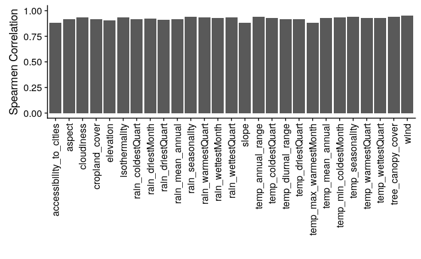

```r
cor_spear <- mapply(function(x,y) cor(x, as.integer(y),method = "spearman"), country_env_df_for_pca, country_env_df_for_mca)
#columns = colnames(country_env_df_for_pca)
#cor_df <- data.frame(col = columns, corr = cor_spear)
cor_p <- as.data.frame(cor_spear)

ggplot(data=cor_p, aes(x=rownames(cor_p), y=cor_p$cor_spear)) +
    geom_bar(stat="identity") + theme(axis.text.x=element_text(angle=90,hjust=1,vjust=0.5)) +
  xlab("") + ylab("Spearmen Correlation") + ylim(0, 1)
```

```r
NA
NA
```

### Correlation Plot

Visually analyze multicollinearity in the system of the original data

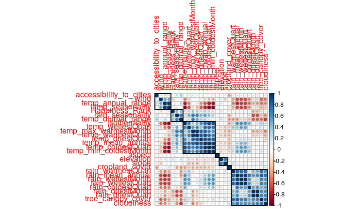

```r
corr_result = cor(country_env_df_for_corr)
corrplot(corr_result,order = 'hclust', addrect = 7)
```

### Heatmap

For binned data.

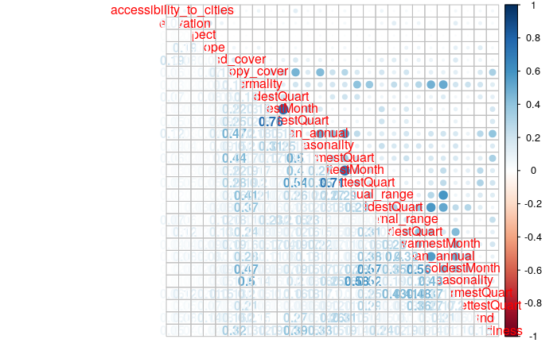

```r
corrMatBurt.list <- phi2Mat4BurtTable(country_env_df_for_mca)
corr4MCA <- corrplot.mixed(as.matrix(corrMatBurt.list$phi2.mat,
                                     title = "Phi2: (squared) Correlation Map for MCA"))
```

```r
a0001a.corMat.phi2 <- recordPlot()
```

## Identify Latent Components - MCA (With Inference)

### Scree Plot

Gives amount of information explained by corresponding component. Gives an intuition to decide which components best represent data in order to answer the research question.

P.S. The most contribution component may not always be most useful for a given research question.

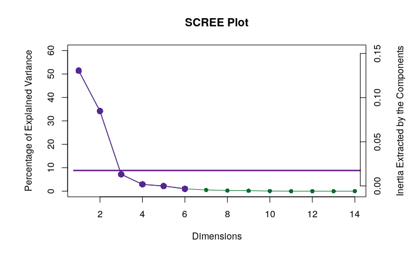

```r
PTCA4CATA::PlotScree(ev = country_env_mca$ExPosition.Data$eigs,
                      p.ev =  country_env_mca_inf$Inference.Data$components$p.vals,
                      title = 'SCREE Plot',
                      plotKaiser = TRUE
)
```

### Factor Scores

**With Confidence Interval**

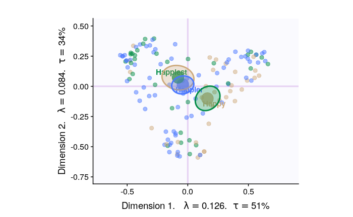

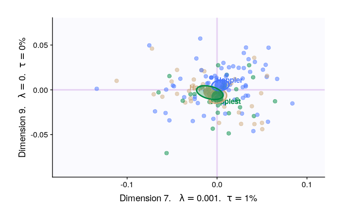

**With Tolerance Interval**

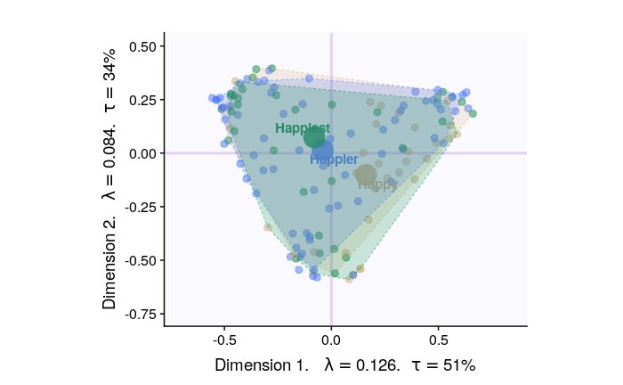

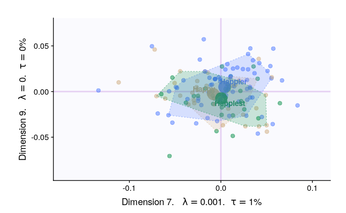

#### Loadings

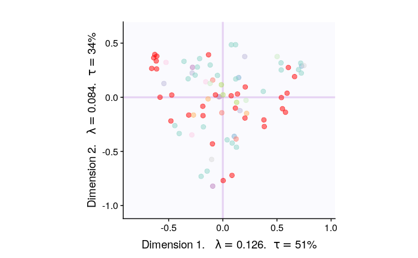

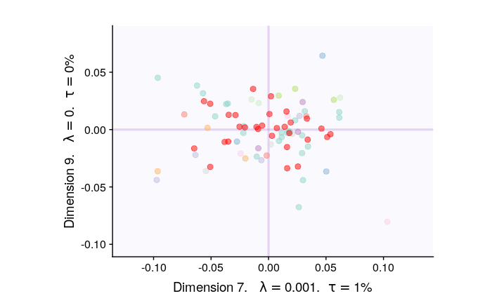

#### Loadings (correlation plot)

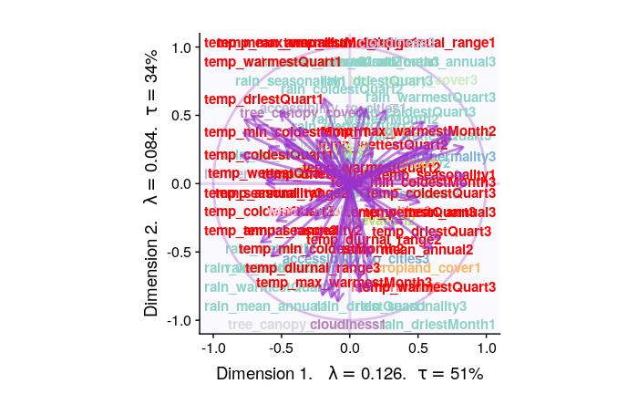

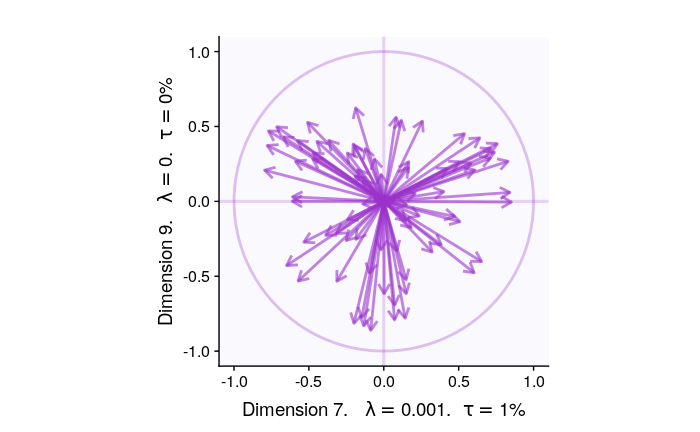

#### Most Contributing Variables (Inference)

Let’s plot variable contributions against each chosen components i.e. 1, 2, 7, 9.

- With Bootstrap Ratio

[figure not shown]

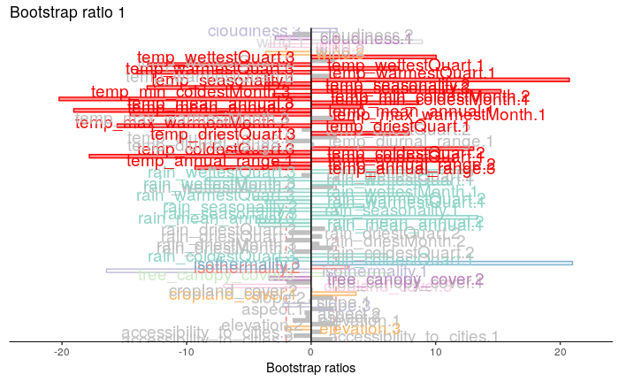

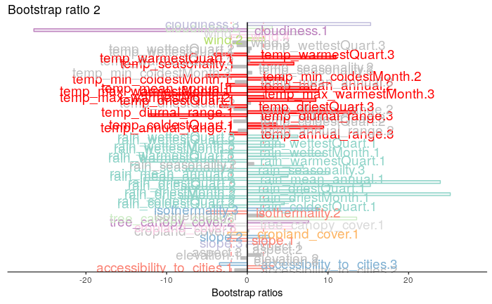

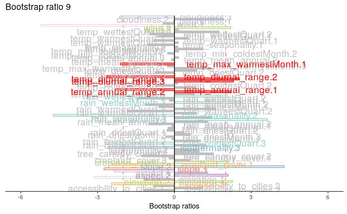

```r
BR <- country_env_mca_inf$Inference.Data$fj.boots$tests$boot.ratios

for (i in c(1, 2, 7, 9)) {
  laDim = i
  ba001.BR1 <- PrettyBarPlot2(BR[,laDim],
                              threshold = 2,
                              font.size = 5,
                              color4bar = gplots::col2hex(col4J), # we need hex code
                              main = paste0('Bootstrap ratio ',laDim),
                              ylab = 'Bootstrap ratios',horizontal = FALSE
                              #ylim = c(1.2*min(BR[,laDim]), 1.2*max(BR[,laDim]))
  )
  print(ba001.BR1)
}
```

```r
#length(BR[,9])
#length(col4J)
```